# 小地域統計による人口変化の可視化

小田原市の例

[岩田真一郎](https://shinichiro-iwata.github.io/)（ [神奈川大学経済学部](https://www.econ.kanagawa-u.ac.jp/)）

2022-06-30作成，2024-03-31改定

# 1 目的

2年分のデータを用いて国勢調査の小地域（町丁・字等別，ポリゴン）に人口変化及び人口変化率を示す．

ライブラリ：`sf`，`tidyverse`

```r
library(sf)
library(tidyverse)
```

# 2 小地域の人口の可視化

**境界データのダウンロード**

- [統計地理情報システム](https://www.e-stat.go.jp/gis) > 境界データダウンロード > 小地域 > 国勢調査 > 2020年（または2010年） > 小地域（町丁・字等別）（JGD2000[^foot1]） > 世界測地系緯度経度・Shapefile > 14206 小田原市

```r
#2020年
Odawara_shi_map20 <-
  read_sf("A002005212020DDSWC14206/r2ka14206.shp")

#2010年
Odawara_shi_map10 <-
  read_sf("A002005212010DDSWC14206/h22ka14206.shp")
```

**統計データのダウンロード**

- [統計地理情報システム](https://www.e-stat.go.jp/gis) > 統計データダウンロード > 小地域 > 国勢調査 > 2020年（または2010年） > 小地域（町丁・字等別） > 男女別人口総数及び世帯総数 > 14神奈川県
  - データはテキスト形式．`read.table`で読込．
    - `Kanagawa_pop#`と名付ける．
    - `header=TRUE`は列名が含まれていることを意味する．仮に列名がなければ`FALSE`．ダウンロードしたデータは2列にわたって列名がある．
    - `sep=","`はデータがカンマで区切られていることを意味する．`skip=1`は1番最初の行を削除することを意味する．後ほど，1行目にあった情報を再度加える．
    - `fileEncoding="CP932"`：文字化け防止．

```r
#2020年
Kanagawa_pop20 <-
  read.table("tblT001081C14/tblT001081C14.txt",
             header=TRUE, sep=",", skip=1,
             fileEncoding="CP932")

#列名の変更（1～4列目）
Kanagawa_pop20 %>%
  rename("KEY_CODE"=1,
         "HYOSYO"=2,
         "CITYNAME"=3,
         "NAME"=4) ->
  Kanagawa_pop20

#2010年（文字化けする場合はオプションを加える）
Kanagawa_pop10 <-
  read.table("tblT000572C14/tblT000572C14.txt",
             header=TRUE, sep=",", skip=1,
             fileEncoding="CP932")

#列名の変更（1～4列目）
Kanagawa_pop10 %>%
  rename("KEY_CODE"=1,
         "HYOSYO"=2,
         "CITYNAME"=3,
         "NAME"=4) ->
  Kanagawa_pop10
```

- 便宜上，小田原市の人口総数だけを抜き出す（`filiter`）．`Odawara_shi_pop#`と名付ける．

```r
Kanagawa_pop20 %>%
  filter(CITYNAME=="小田原市") ->
  Odawara_shi_pop20

Kanagawa_pop10 %>%
  filter(CITYNAME=="小田原市") ->
  Odawara_shi_pop10
```

**人口総数**

小地域の人口は「人口総数」の列に含まれているが，文字情報．

- 数値（`numeric`）情報に変更（`mutate`）する．再び `Odawara_shi_pop_#`と名付ける．
  - 欠損値（データに「-」含まれる）は`NA`に強制変換（`Warning message`（警告メッセージ）が出現するが問題ない）．

```r
#2020年
Odawara_shi_pop20 %>%
  mutate(人口総数=as.numeric(人口総数)) ->
  Odawara_shi_pop20

#2010年
Odawara_shi_pop10 %>%
  mutate(人口総数=as.numeric(人口総数)) ->
  Odawara_shi_pop10
```

**データ結合1**

各年の境界データと統計データを結合．

- **注意**：境界データの`KEY_CODE`が`character`（文字データ），統計データは`integer`（数データ）のため結合できない．
  - そこで，統計データ（`Odawara_shi_pop_#`）の`KEY_CODE`を`character`に変換（`mutate`）する．再度，`Odawara_shi_pop_#`と名付ける．
- `KEY_CODE`で結合し，`Odawara_shi#`と名付ける．

```r
#文字データへの変換
Odawara_shi_pop20 %>%
  mutate(KEY_CODE=as.character(KEY_CODE)) ->
  Odawara_shi_pop20

Odawara_shi_pop10 %>%
  mutate(KEY_CODE=as.character(KEY_CODE)) ->
  Odawara_shi_pop10

#データの結合
Odawara_shi20 <-
  left_join(Odawara_shi_map20, Odawara_shi_pop20,
          by=c("KEY_CODE"))

Odawara_shi10 <-
  left_join(Odawara_shi_map10, Odawara_shi_pop10,
          by=c("KEY_CODE"))
```

**人口分布の可視化**

境界データにも小地域の人口（`JINKO`）が含まれている．したがって，人口だけを見るのであれば，統計データを結合する必要ないが，統計データの「人口総数」と値が異なる小地域が存在．

- 下の図で確認．例えば黄色の枠の箇所．境界データではこの箇所は`0`．

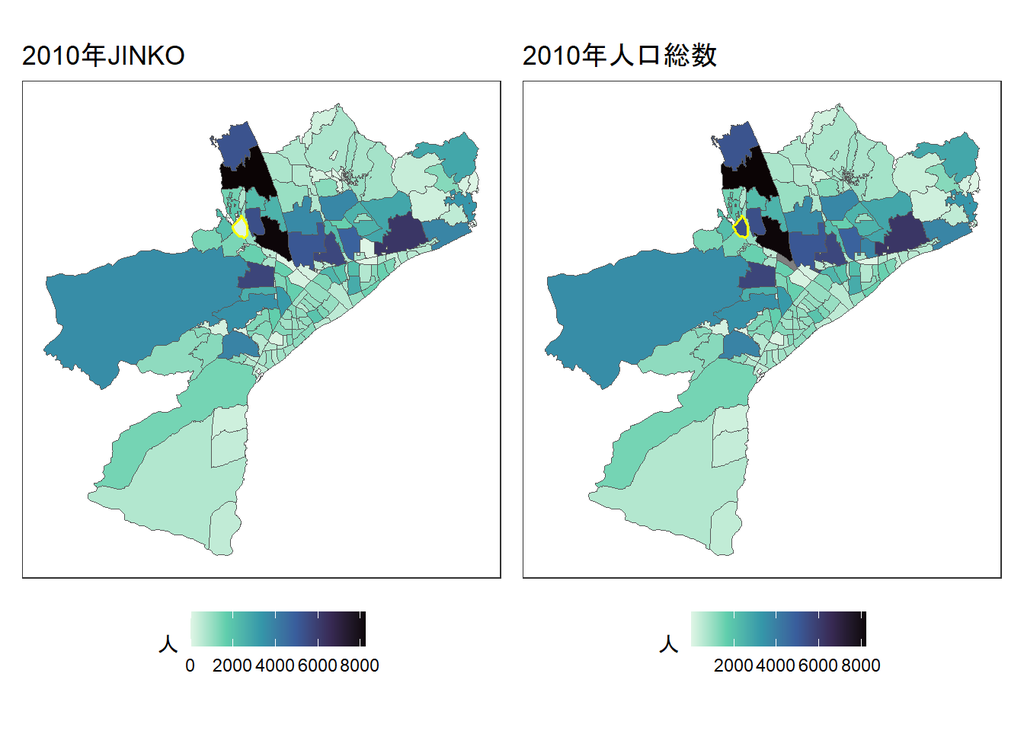

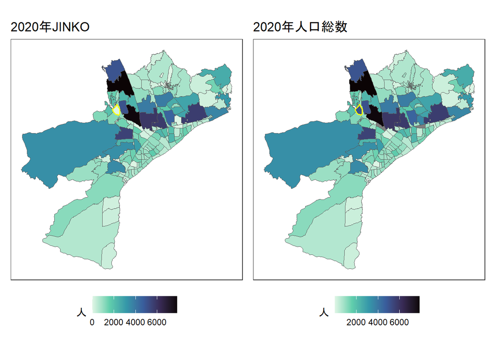

# 3 統計データによる人口変化の可視化

統計データを用いて人口変化（増減）と人口変化（増減）率を計算．

**データ結合2**

2010年と2020年のデータを横方向に結合．

- `cbind()`：データを横方向に結合．右側（`Odawara_shi20`）のデータの列名はすべて「～.1」に自動変更．

```r
Odawara_shi<-
  cbind(Odawara_shi10, Odawara_shi20)
```

**人口変化と人口変化率**

- 2020年の人口総数（人口総数.1）から2010年の人口総数（人口総数）を引き，人口変化をとらえる．計算された列を`diff_pop`と名付ける．
- 変化率の計算式は（2020年人口ー2010年の人口）／2010年の人口）×100）の通り．計算された列を`pop_rate`と名付ける．

```r
#人口変化
Odawara_shi %>%
  mutate(diff_pop=人口総数.1-人口総数) ->
  Odawara_shi

#人口変化率
Odawara_shi %>%
  mutate(pop_rate=(人口総数.1-人口総数)/人口総数*100) ->
  Odawara_shi
```

**完成図**

完成図の可視化．

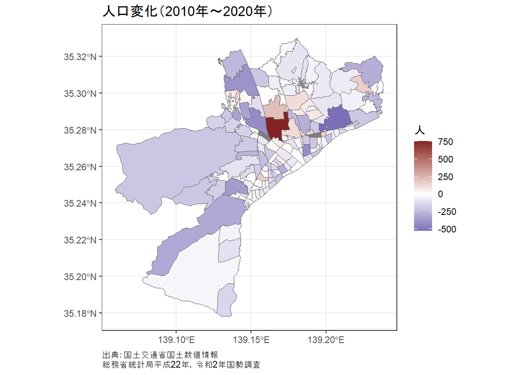

```r
#muted()利用
library(scales)

#人口変化の可視化
ggplot()+
  geom_sf(data=Odawara_shi, aes(fill=diff_pop))+
  scale_fill_gradient2(low=muted("blue"),
                       mid="white",
                       high=muted("red"))+
  labs(fill="人",
  caption="出典：国土交通省国土数値情報
総務省統計局平成22年，令和2年国勢調査")+
  ggtitle("人口変化（2010年～2020年）")+
  theme_bw()+
  theme(plot.caption=element_text(hjust=0))
```

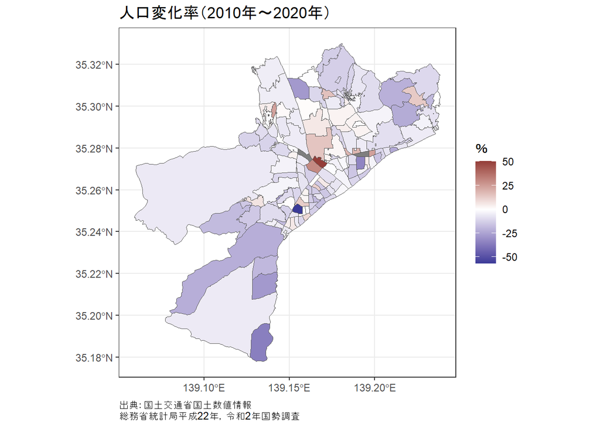

```r
#人口変化率の可視化
ggplot()+
  geom_sf(data=Odawara_shi, aes(fill=pop_rate))+
  scale_fill_gradient2(low=muted("blue"),
                       mid="white",
                       high=muted("red"))+
  labs(fill="％",
  caption="出典：国土交通省国土数値情報
総務省統計局平成22年，令和2年国勢調査")+
  ggtitle("人口変化率（2010年～2020年）")+
  theme_bw()+
  theme(plot.caption=element_text(hjust=0))
```

**Rによる地理空間データの可視化**

- チュートリアル[ホーム](https://shinichiro-iwata.github.io/geospatial-data-visualization/)